# Bayesian Conditional Autoregression Models in “rjags”

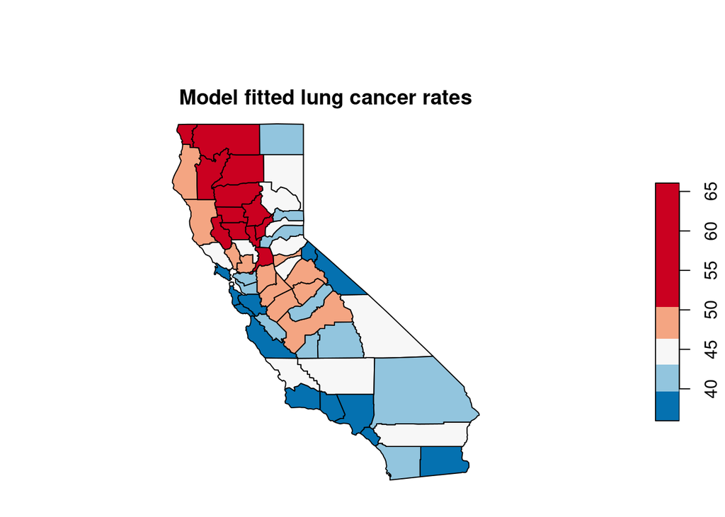

```r
plot(caCountySF["ModelFitted"], pal = colorPalette, breaks = brksModelFitted, main = "Model fitted lung cancer rates")
```

17. Model assessment: How good is this model? Is it “adequate”? Find the correlation between the model fitted values and the observed data. Then plot fitted values against raw data

```r
cor(Y, yFitPosteriorMedians) ## correlation between observed and model fitted values
```

```
## [1] 0.9222993
```

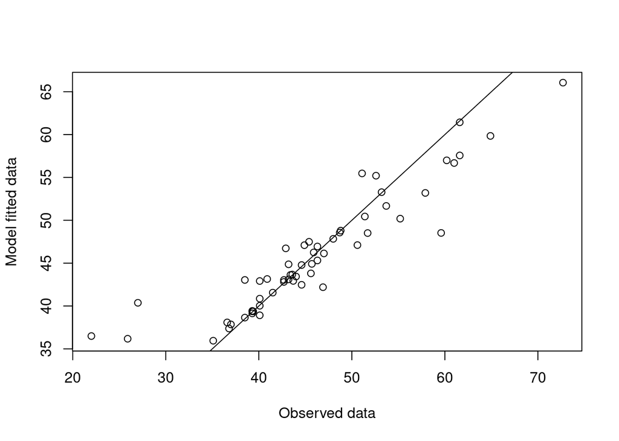

```r
plot(Y, yFitPosteriorMedians, xlab="Observed data", ylab="Model fitted data")
abline(0,1) ## adds the 45 degree (y=x) line to identify departures of fitted values from observations.
```

18. Our next step will be to assign a score for this model based upon the posterior distribution of fitted values. This distribution is $p(yFit \mid Y)$ and the resulting model fitted values are referred to as model replicated data. We first extract the posterior samples of “yFit” from “samps”.

```r
yFitSamps <- samps[,grep("yFit", colnames(samps))]
```

19. We define a goodness of fit measure “G” based on the sum of squared differences between the observations and the means of the replicated data for each data point.

```r
G <- sum((Y - colMeans(yFitSamps))^2)
G
```

```
## [1] 1166.469
```

20. We define a measure of penalty “P” that penalizes the complexity of the model based upon sum of the variances of the replicated data for each data point.

```r
P <- sum(apply(yFitSamps, 2, function (x) {var(x)} ))
P
```

```
## [1] 2766.941
```

21. Finally, we define a model assessment score “D=G+P” for this model. This score is useful for model comparisons. The smaller the score, the better the model.

```r
D <- G+P
D
```

```
## [1] 3933.409
```

22. Let us compare the D score of the spatial model with that of a simple linear regression model. We will again run 3 chains in our MCMC algorithm. We will need initial values for the model parameters, specify model parameters to monitor and run the model following essentially the same steps as for the spatial model. We run the code in one example block for convenience. You are, by now, quite familiar with these steps so a bit of quick documentation will not hurt.

```r
inits = list(
         list(beta=rep(0,times=p), tausq=1.0, yFit = rep(0, times=N)),
         list(beta=rep(-100, times=p), tausq=1.0, yFit = rep(0, times=N)),
         list(beta=rep(100,times=p), tausq=1.0, yFit = rep(0, times=N))
)

model.parameters = c("beta", "tausq", "sigma", "yFit")

m2 <- jags.model("../src/model_jags_simpleLM.txt", data=jagsDataSimpleLM, inits = inits, n.chains=nChains, n.adapt = nAdapt, quiet=TRUE)

update(m2, n.iter=nBurn)
```

[output not shown]

```r
m2.out <- coda.samples(model=m2, variable.names=model.parameters, n.iter=nSamp)
```

[output not shown]

```r
samps <- do.call(rbind, m2.out)

credibleIntervals <- t(apply(samps, 2, function(x){quantile(x, c(0.50, 0.025, 0.975))}))
CI_yFit <- credibleIntervals[grep("yFit", rownames(credibleIntervals)),]
yFitPosteriorMedians <- CI_yFit[,grep("50%", colnames(CI_yFit))]
cor(Y, yFitPosteriorMedians) ## correlation between observed and model fitted values
```

```
## [1] 0.620466
```

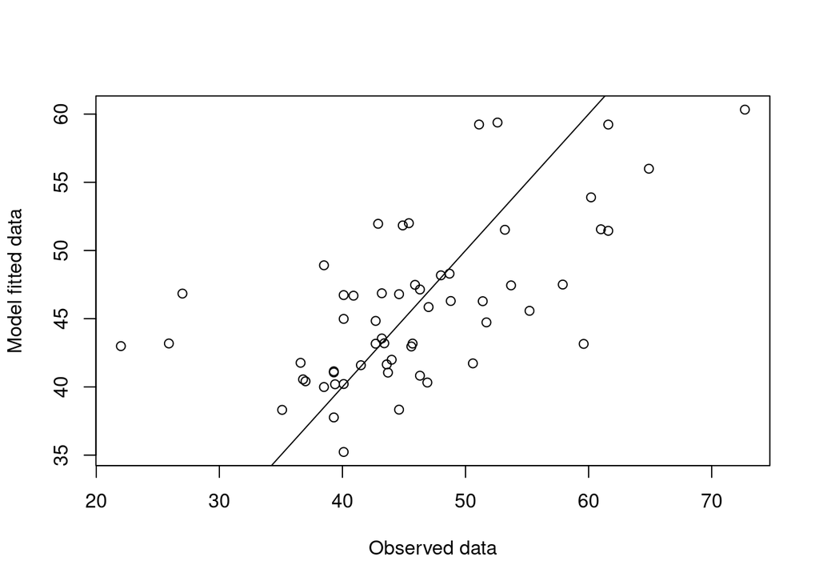

```r
plot(Y, yFitPosteriorMedians, xlab="Observed data", ylab="Model fitted data")
abline(0,1) ## adds the 45 degree (y=x) line to identify departures of fitted values from observations.
```

```r
yFitSamps <- samps[,grep("yFit", colnames(samps))]

G <- sum((Y - colMeans(yFitSamps))^2)
G
```

```
## [1] 3036.109
```

```r
P <- sum(apply(yFitSamps, 2, function (x) {var(x)} ))
P
```

```
## [1] 3375.07
```

```r
D <- G+P
D
```

```
## [1] 6411.179
```

Conclusion: Spatial model is clearly preferred due to its substantially lower D score.